# Tutorial 8

Oh Jian Hui

17/10/2020

# Question 1

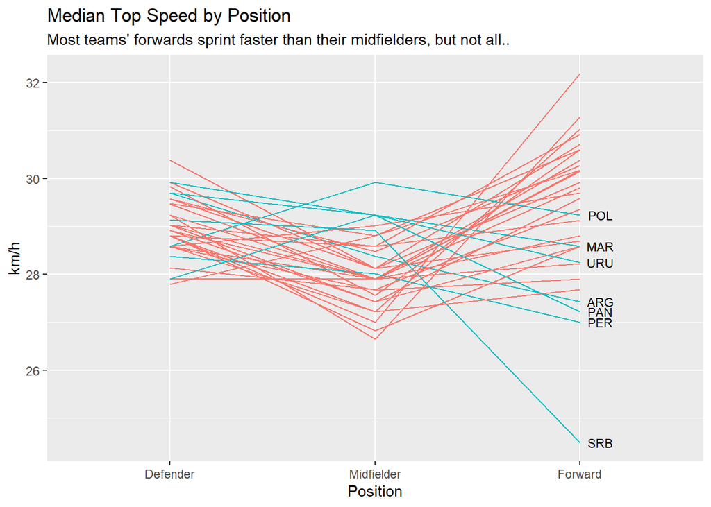

# Question 2

### Time spent by defenders on the oposition half in matches of different stages

For this question, I only consider matches played by teams that have at least reached the knock-out stage. Otherwise, it would be impossible compare whether the teams decided to switch to play more conservatively during the knock-out matches.

Also, only defenders who played at least 45 minutes are considered. This is because a previous plot I made shows that some defenders playing less than 45 minutes clustered far from the rest (but not out of the 1.5 * IQR because they reached the limit of the y-scale), extending the whiskers’ length.

```
## [1] "Group Stage matches"
```

```
## # A tibble: 1 x 1
##   average_in_percent
##                <dbl>
## 1               28.9
```

```
## [1] "Knock-out matches"
```

```
## # A tibble: 1 x 1
##   average_in_percent
##                <dbl>
## 1               26.5
```

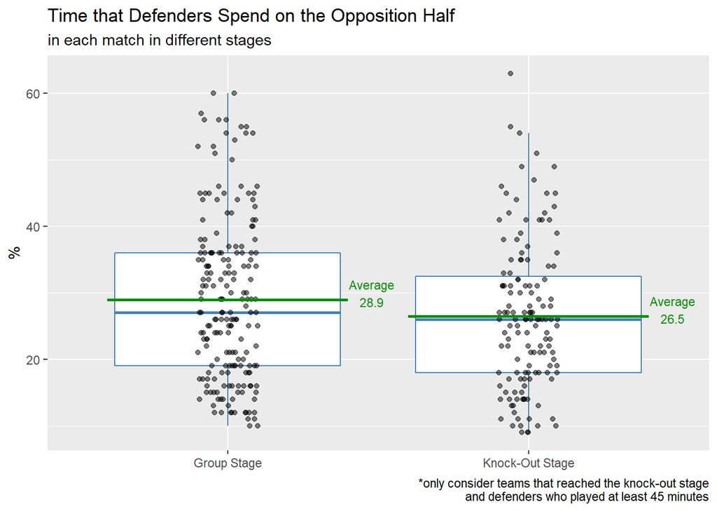

Indeed, in general, the teams switched to play more conservatively during the knock-out stage.  
Since mean is higher than median in general, the two graphs are right-skewed. In group stage matches, the skewness is much higher and the spread is also perceptibly higher.

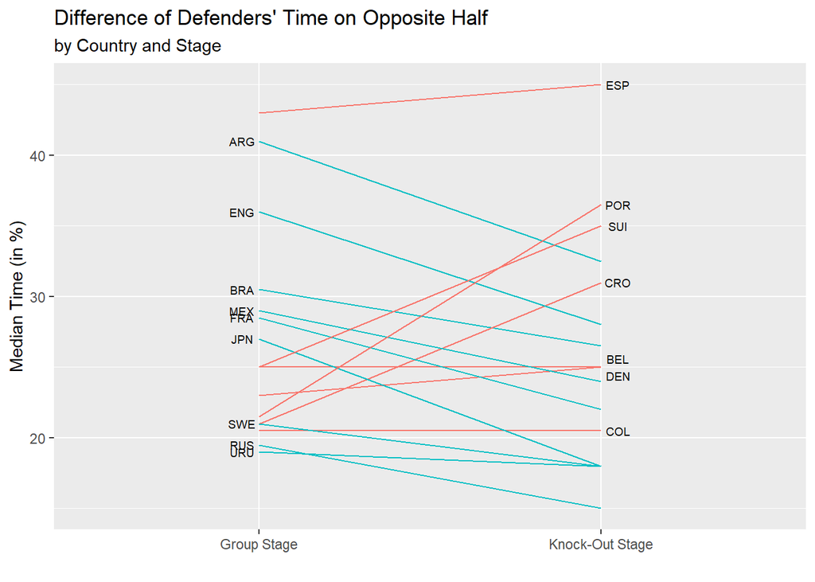